# Predicting Housing Prices Using Multiple Regression

Authors

Author 1

Author 2

Author 3

Author 4

## Introduction

What property characteristics most influence residential sale prices? Answering this question has practical value for home buyers evaluating fair market value, sellers setting listing prices, and appraisers performing valuations. This report builds a multiple linear regression model to predict sale price from structural, locational, and categorical property features recorded in the Saratoga housing dataset.

## Data Set

**Variables.** Predictors span continuous measures (Lot.Size, Age, Land.Value, Living.Area, Pct.College, Bedrooms, Fireplaces, Bathrooms, Rooms), binary indicators (Waterfront, New.Construct, Central.Air), and categorical factors (Fuel.Type, Heat.Type, Sewer.Type). Four sparse Fuel.Type levels (each n ≤ 3) were collapsed into “Other.”

Summary statistics for key variables.

| name | Mean | SD | Min | Max |
| --- | --- | --- | --- | --- |
| Age | 28 | 30 | 0 | 225 |
| Bathrooms | 2 | 1 | 1 | 4 |
| Land.Value | 34418 | 33879 | 200 | 255000 |
| Living.Area | 1756 | 620 | 616 | 5228 |
| Lot.Size | 1 | 1 | 0 | 12 |
| Price | 211887 | 97474 | 20000 | 775000 |
| Rooms | 7 | 2 | 2 | 12 |

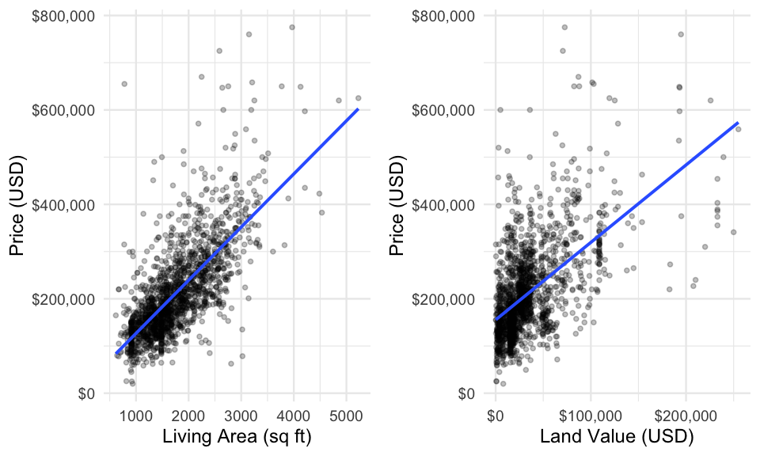

Scatter plots of two key continuous predictors against Price.

## Analysis

**Assumptions.** Each observation represents a distinct property transaction, so the independence assumption (that rows are independent of one another) is reasonable. Residual diagnostic plots are shown below.

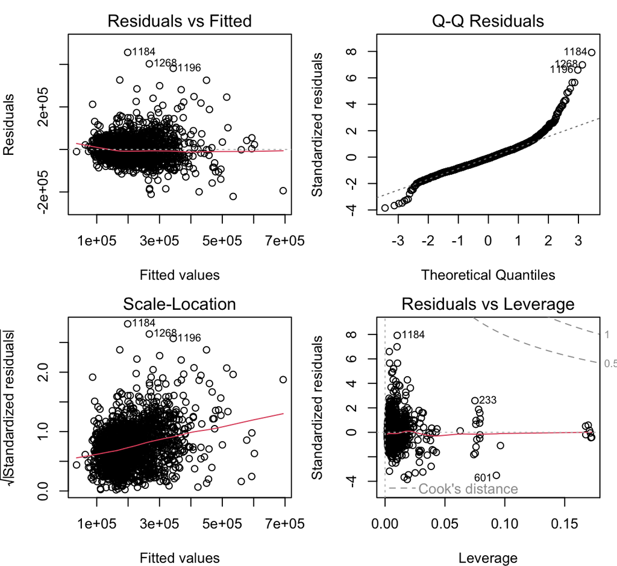

Residual diagnostic plots for the final model.

The residuals-versus-fitted plot shows no strong curvature, supporting the linearity assumption. However, the spread of residuals fans outward at higher fitted values, indicating some heteroscedasticity, and the Q–Q plot reveals right-skew in the upper tail. These departures suggest that coefficient estimates remain unbiased but standard errors may be somewhat understated for the highest-priced homes. A log transformation of Price was explored but altered the set of significant predictors and complicated coefficient interpretation; the untransformed model was retained for clarity, and the residual non-normality is noted as a limitation.

## Results

Final model coefficient estimates with 95% confidence intervals.

| Term | Estimate | SE | p-value | CI Low | CI High |
| --- | --- | --- | --- | --- | --- |
| (Intercept) | 8159.03 | 6578.64 | 0.22 | -4744.01 | 21062.07 |
| Lot.Size | 7317.52 | 2033.64 | 0.00 | 3328.82 | 11306.22 |
| Waterfront1 | 119174.63 | 15673.65 | 0.00 | 88433.05 | 149916.22 |
| Age | -139.10 | 56.55 | 0.01 | -250.00 | -28.19 |
| Land.Value | 0.92 | 0.05 | 0.00 | 0.82 | 1.01 |
| New.Construct1 | -44620.17 | 7117.58 | 0.00 | -58580.27 | -30660.07 |
| Central.Air1 | 9814.09 | 3381.14 | 0.00 | 3182.48 | 16445.71 |
| Heat.TypeHot Air | 9700.90 | 4048.34 | 0.02 | 1760.67 | 17641.13 |
| Heat.TypeHot Water | -834.64 | 5200.37 | 0.87 | -11034.42 | 9365.13 |
| Heat.TypeNone | -33595.05 | 24621.00 | 0.17 | -81885.56 | 14695.46 |
| Living.Area | 69.36 | 4.49 | 0.00 | 60.55 | 78.18 |
| Bedrooms | -8109.00 | 2541.78 | 0.00 | -13094.32 | -3123.67 |
| Bathrooms | 23964.75 | 3324.32 | 0.00 | 17444.58 | 30484.93 |
| Rooms | 3142.26 | 958.50 | 0.00 | 1262.31 | 5022.21 |

**Key coefficient interpretations** (holding other predictors constant):

- **Living.Area:** each additional 100 sq ft of living space is associated with an approximately $6,936 increase in price (range in data: 616 – 5,228 sq ft).
- **Land.Value:** a $10,000 increase in assessed land value corresponds to roughly $9,167 higher sale price.
- **Bathrooms:** each additional bathroom adds about $23,965 (range: 1–4.5).
- **Waterfront:** waterfront properties sell for approximately $119,175 more, though this estimate is based on only 14 waterfront homes and should be interpreted with caution.
- **New.Construct:** newly constructed homes are associated with a $44,620 *lower* price after controlling for other features, likely because new builds in this market tend to occupy lower-valued land.
- **Bedrooms:** an additional bedroom is associated with a $8,109 *decrease* in price once living area and rooms are held constant, reflecting the trade-off between more bedrooms and smaller room sizes within a fixed footprint.

## Discussion & Conclusion

This model explains roughly 65% of the variance in Saratoga housing prices. Living area, land value, and bathrooms are the strongest positive value drivers, while waterfront access carries the single largest price premium. These findings are consistent with conventional real-estate intuition: space, location quality, and desirable amenities command higher prices.

**Limitations.** The data are observational, so no causal claims can be made — for instance, adding a bathroom does not guarantee a $23,000 return. The right-skewed residuals and mild heteroscedasticity mean that predictions for the most expensive homes carry wider uncertainty than the model implies. Additionally, potentially important predictors such as school district, neighbourhood desirability, and property condition are not captured. The dataset is specific to Saratoga, NY, and the model may not transfer to other housing markets with different price distributions or regional preferences.

**Overcoming limitations.** Future work could incorporate spatial variables (e.g. distance to amenities, school ratings) and apply robust standard errors or a log transformation to better handle residual non-normality. Expanding the dataset across multiple markets would improve generalisability.

## Appendix

```
Stepwise model formula:
```

```
Price ~ Lot.Size + Waterfront + Age + Land.Value + New.Construct +
    Central.Air + Heat.Type + Living.Area + Bedrooms + Bathrooms +
    Rooms
```

```
Call:
lm(formula = Price ~ Lot.Size + Waterfront + Age + Land.Value +
    New.Construct + Central.Air + Heat.Type + Living.Area + Bedrooms +
    Bathrooms + Rooms, data = train)

Residuals:
    Min      1Q  Median      3Q     Max
-220960  -35036   -4783   27494  456295

Coefficients:
                     Estimate Std. Error t value Pr(>|t|)
(Intercept)         8.159e+03  6.579e+03   1.240  0.21506
Lot.Size            7.318e+03  2.034e+03   3.598  0.00033 ***
Waterfront1         1.192e+05  1.567e+04   7.604 4.73e-14 ***
Age                -1.391e+02  5.655e+01  -2.460  0.01400 *
Land.Value          9.167e-01  4.753e-02  19.286  < 2e-16 ***
New.Construct1     -4.462e+04  7.118e+03  -6.269 4.59e-10 ***
Central.Air1        9.814e+03  3.381e+03   2.903  0.00375 **
Heat.TypeHot Air    9.701e+03  4.048e+03   2.396  0.01667 *
Heat.TypeHot Water -8.346e+02  5.200e+03  -0.160  0.87251
Heat.TypeNone      -3.360e+04  2.462e+04  -1.364  0.17259
Living.Area         6.936e+01  4.494e+00  15.435  < 2e-16 ***
Bedrooms           -8.109e+03  2.542e+03  -3.190  0.00145 **
Bathrooms           2.396e+04  3.324e+03   7.209 8.44e-13 ***
Rooms               3.142e+03  9.585e+02   3.278  0.00107 **
---
Signif. codes:  0 '***' 0.001 '**' 0.01 '*' 0.05 '.' 0.1 ' ' 1

Residual standard error: 57910 on 1707 degrees of freedom
Multiple R-squared:  0.6497,    Adjusted R-squared:  0.647
F-statistic: 243.6 on 13 and 1707 DF,  p-value: < 2.2e-16
```

```
Full model AIC: 42656.9
```

```
Step model AIC: 42647.08
```